# chapter_three_assignment

Veronica Thompson

April 12, 2019

### Chapter 3

#### April 19 2019

#### 3.1. Sampling from a grid-approximate posterior

```r
#calculate posterior for globe model
p_grid <- seq( from=0 , to=1 , length.out=1000 )
prob_p <- rep( 1 , 1000 )
prob_data <- dbinom( 6 , size=9 , prob=p_grid )
posterior <- prob_data * prob_p
posterior <- posterior / sum(posterior)
```

```r
#sample the posterior
samples <- sample(p_grid , prob=posterior , size=1e4 , replace=TRUE)
```

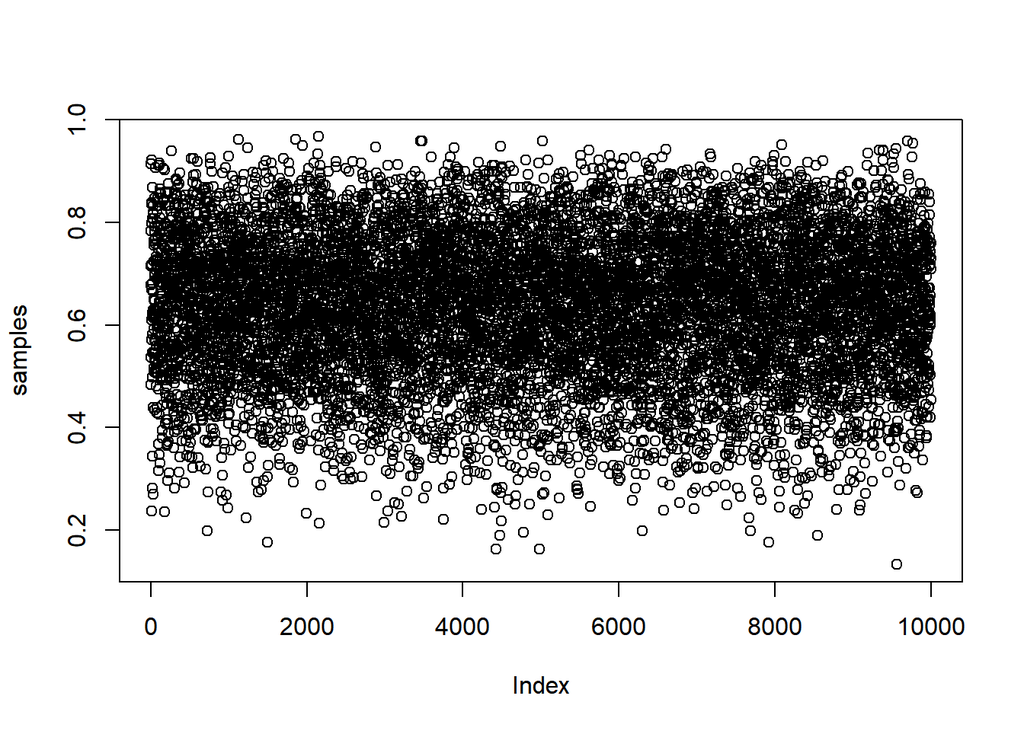

```r
#plot samples
plot(samples)
```

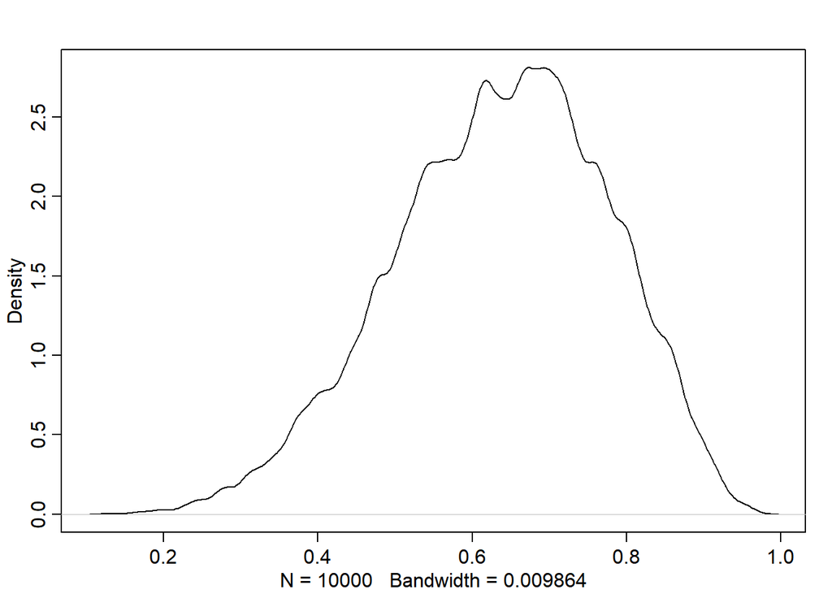

```r
#frequency plot samples
dens(samples)
```

#### 3.2. Sampling to summarize

##### 3.2.1 Intervals of defined boundaries

Q: what is the probability that there is less than 50% water on Earth

Using the model, *not good for more complex models*

```r
# add up posterior probability where p < 0.5
sum( posterior[ p_grid < 0.5 ] )
```

```
## [1] 0.1718746
```

Using samples from the posterior probability distribution, *much better for complex models*

```r
# sum of samples / sample size
sum( samples < 0.5 ) / 1e4
```

```
## [1] 0.1687
```

Q: probability water is between .5 and .75 of Earth’s surface

```r
#from sample of posterior
sum( samples > 0.5 & samples < 0.75 ) / 1e4
```

```
## [1] 0.6095
```

#### 3.2.2 Intervals of defined mass (confidence interval)

report two parameter values that contain a specific mass of the probability between them  
ex: 95% confidence intervals is two values between which 95% of the mass of probability falls

Q: Boundaries of lower 80% quantile

```r
#p = 0 is lowest boundary
quantile( samples , 0.8 )
```

```
##       80%
## 0.7597598
```

Q: boundaries of middle 80%, *good as long as data is not assymmetrical*

```r
quantile( samples , c( 0.1 , 0.9 ) )
```

```
##       10%       90%
## 0.4504505 0.8108108
```

Assymmetrical data

```r
#highly skewed data (3 water, flat prior for earth example)
p_grid <- seq( from=0 , to=1 , length.out=1000 )
prior <- rep(1,1000)
likelihood <- dbinom( 3 , size=3 , prob=p_grid )
posterior <- likelihood * prior
posterior <- posterior / sum(posterior)
samples <- sample( p_grid , size=1e4 , replace=TRUE , prob=posterior )
```

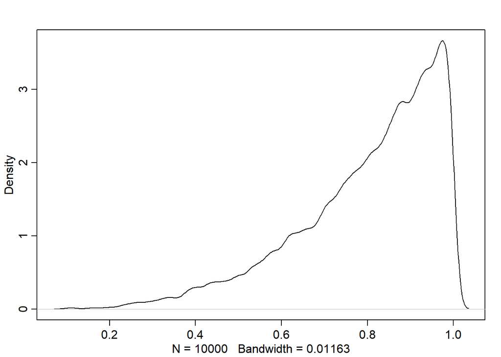

```r
dens(samples)
```

```r
#calculate percentile interval, from rethinking package
PI( samples , prob=0.5 )
```

```
##       25%       75%
## 0.7097097 0.9301802
```

```r
#misleading result given shape
```

Highest Posterior Density Interval (HPDI)  
narrowest interval containing a probability mass  
very representative of data  
not much differrent from another central interval unless data is skewed, as above  
sensitive to sample size

Q: HDPI 50% interval

```r
#HPDI from Rethinking package
HPDI(samples, prob = 0.5)
```

```
##      |0.5      0.5|
## 0.8418418 1.0000000
```

#### 3.2.3 Point Estimates

*maximum a posteriori* (MAP)

```r
#from model
p_grid[ which.max(posterior) ]
```

```
## [1] 1
```

```r
#from samples
chainmode( samples , adj=0.01 )
```

```
## [1] 0.9831578
```

weighted loss for one value

```r
sum( posterior*abs( 0.5 - p_grid ) )
```

```
## [1] 0.3128752
```

weighted loss for all values

```r
loss <- sapply( p_grid , function(d) sum( posterior*abs( d - p_grid ) ) )
#then, minumum loss
p_grid[ which.min(loss) ]
```

```
## [1] 0.8408408
```

```r
#same as the median
median(samples)
```

```
## [1] 0.8418418
```

Practice problems:  
3E1-7  
3M1-4

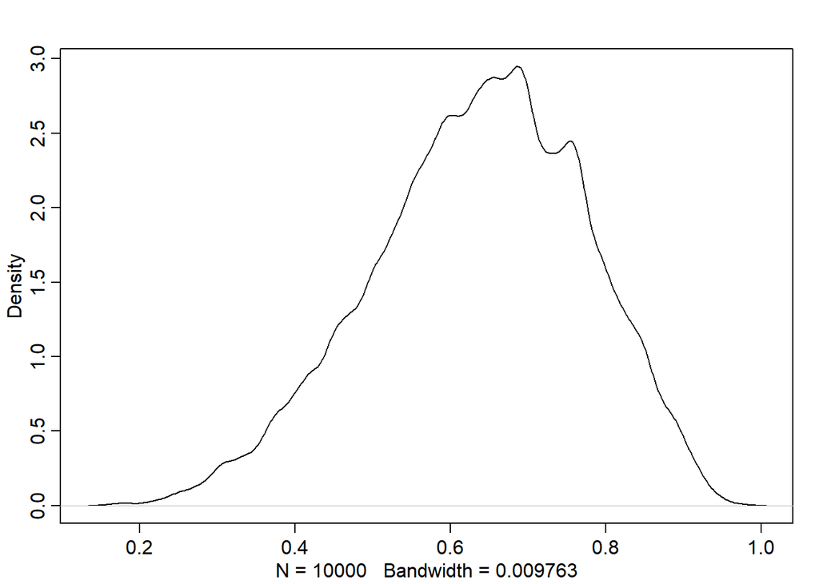

```r
#specific set of samples for this E problems
p_grid <- seq( from=0 , to=1 , length.out=1000 )
prior <- rep( 1 , 1000 )
likelihood <- dbinom( 6 , size=9 , prob=p_grid )
posterior <- likelihood * prior
posterior <- posterior / sum(posterior)
set.seed(100)
samples <- sample( p_grid , prob=posterior , size=1e4 , replace=TRUE )
dens(samples)
```

**3E1.** How much posterior probability lies below p = 0.2?

```r
sum( samples < 0.2 ) / 1e4
```

```
## [1] 5e-04
```

**3E2.** How much posterior probability lies above p = 0.8?

```r
sum(samples > 0.8) /1e4
```

```
## [1] 0.1117
```

**3E3.** How much posterior probability lies between p = 0.2 and p = 0.8?

```r
sum(samples > 0.2 & samples < 0.8) /1e4
```

```
## [1] 0.8878
```

```r
#sum of all to check
5e-04+.1117+.8878
```

```
## [1] 1
```

**3E4.** 20% of the posterior probability lies below which value of p?

```r
quantile(samples, .2)
```

```
##       20%
## 0.5195195
```

**3E5.** 20% of the posterior probability lies above which value of p?

```r
quantile(samples, .8)
```

```
##       80%
## 0.7567568
```

**3E6.** Which values of p contain the narrowest interval equal to 66% of the posterior probability?

```r
HPDI(samples, prob = .66 )
```

```
##     |0.66     0.66|
## 0.5205205 0.7847848
```

**3E7.** Which values of p contain 66% of the posterior probability, assuming equal posterior probability both below and above the interval?

```r
quantile(samples, c(.17, .83))
```

```
##       17%       83%
## 0.5005005 0.7687688
```

**3M1.** Suppose the globe tossing data had turned out to be 8 water in 15 tosses. Construct the posterior distribution, using grid approximation. Use the same flat prior as before.

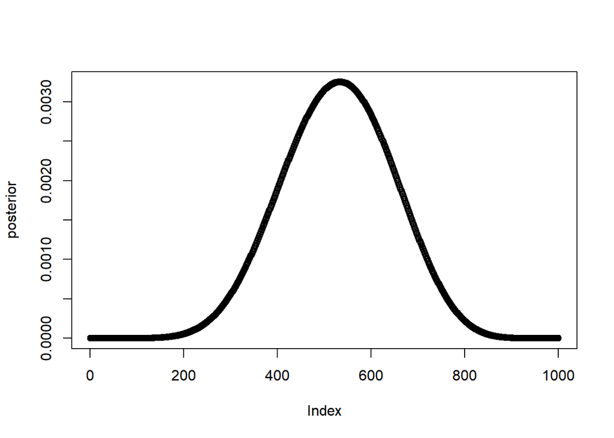

```r
p_grid = seq(from = 0, to = 1, length.out = 1000) #flat prior
prior = rep(1, 1000)
likelihood = dbinom(8, size = 15, prob = p_grid)
posterior = likelihood * prior
posterior = posterior / sum(posterior)
plot (posterior)
```

**3M2.** Draw 10,000 samples from the grid approximation from above. Then use the samples to calculate the 90% HPDI for p.

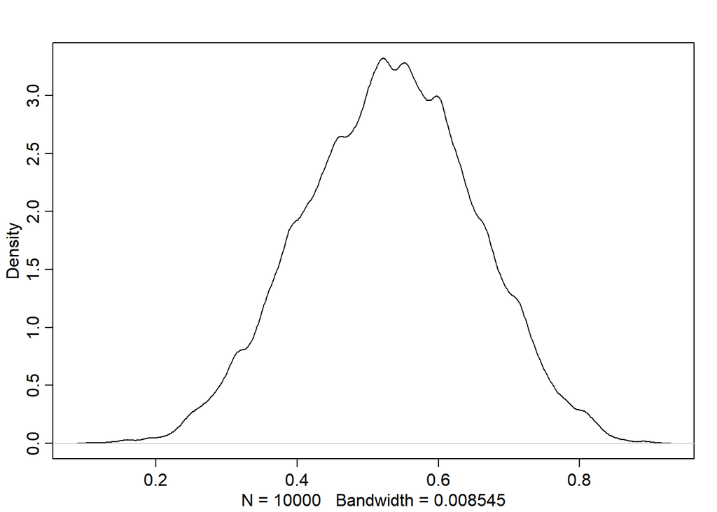

```r
samples = sample(p_grid, size = 1e4, replace = TRUE, prob = posterior)
dens(samples)
```

```r
HPDI(samples, prob = .90)
```

```
##      |0.9      0.9|
## 0.3383383 0.7317317
```

```r
predictions <- rbinom(10000, 9, prob = samples)
sum(predictions==6) / length(predictions)
```

```
## [1] 0.1774
```